# Project: Investigate The Movie Database

- Introduction
- Data Wrangling
- Exploratory Data Analysis
- Conclusions

## Introduction

> **DataSet Description:**

> > This data-set contains information about 10,000 movies collected from The Movie Database (TMDb), including genres , cast , user-ratings ,revenue.

> **Questions to be answered through the project:**
> > 1. Which genres are most popular from year to year?
> > 2. What kinds of properties are associated with movies that have high revenues?
> > 3. What is the director name who has the most top yearly-voting rate over all years?
> > 4. which month mostly has the highest movies number released for last 10 years ?
> > 5. which genres have the highest mean revenues over the last 10 years ?

```python
# import Libraries
import pandas as pd
import numpy as np
import matplotlib.pyplot as plt
import seaborn as sns
%matplotlib inline
```

## Data Wrangling

**Loading our dataset and Looking into first 4-lines in our dataset**

```python
df_org = pd.read_csv('tmdb-movies.csv')
```

```python
df_org.head(4)
```

|  | id | imdb_id | popularity | budget | revenue | original_title | cast | homepage | director | tagline | ... | overview | runtime | genres | production_companies | release_date | vote_count | vote_average | release_year | budget_adj | revenue_adj |
| --- | --- | --- | --- | --- | --- | --- | --- | --- | --- | --- | --- | --- | --- | --- | --- | --- | --- | --- | --- | --- | --- |
| 0 | 135397 | tt0369610 | 32.985763 | 150000000 | 1513528810 | Jurassic World | Chris Pratt\|Bryce Dallas Howard\|Irrfan Khan\|Vi... | http://www.jurassicworld.com/ | Colin Trevorrow | The park is open. | ... | Twenty-two years after the events of Jurassic ... | 124 | Action\|Adventure\|Science Fiction\|Thriller | Universal Studios\|Amblin Entertainment\|Legenda... | 6/9/15 | 5562 | 6.5 | 2015 | 1.379999e+08 | 1.392446e+09 |
| 1 | 76341 | tt1392190 | 28.419936 | 150000000 | 378436354 | Mad Max: Fury Road | Tom Hardy\|Charlize Theron\|Hugh Keays-Byrne\|Nic... | http://www.madmaxmovie.com/ | George Miller | What a Lovely Day. | ... | An apocalyptic story set in the furthest reach... | 120 | Action\|Adventure\|Science Fiction\|Thriller | Village Roadshow Pictures\|Kennedy Miller Produ... | 5/13/15 | 6185 | 7.1 | 2015 | 1.379999e+08 | 3.481613e+08 |
| 2 | 262500 | tt2908446 | 13.112507 | 110000000 | 295238201 | Insurgent | Shailene Woodley\|Theo James\|Kate Winslet\|Ansel... | http://www.thedivergentseries.movie/#insurgent | Robert Schwentke | One Choice Can Destroy You | ... | Beatrice Prior must confront her inner demons ... | 119 | Adventure\|Science Fiction\|Thriller | Summit Entertainment\|Mandeville Films\|Red Wago... | 3/18/15 | 2480 | 6.3 | 2015 | 1.012000e+08 | 2.716190e+08 |
| 3 | 140607 | tt2488496 | 11.173104 | 200000000 | 2068178225 | Star Wars: The Force Awakens | Harrison Ford\|Mark Hamill\|Carrie Fisher\|Adam D... | http://www.starwars.com/films/star-wars-episod... | J.J. Abrams | Every generation has a story. | ... | Thirty years after defeating the Galactic Empi... | 136 | Action\|Adventure\|Science Fiction\|Fantasy | Lucasfilm\|Truenorth Productions\|Bad Robot | 12/15/15 | 5292 | 7.5 | 2015 | 1.839999e+08 | 1.902723e+09 |

4 rows × 21 columns

We can observe that we have **21 columns**. Also, we can see that certain columns contain multiple values separated by pipe (|) characters like **‘cast’** and **‘genres’** and **'director'** and **'production_companies'**

**Exploring more information about our dataset like:**

> dataset shape:num of cloumns and num of rows , datatype of each feature(column), Null Count if exist (missing) in each coloumn.

```python
df_org.info()
```

```
<class 'pandas.core.frame.DataFrame'>
RangeIndex: 10866 entries, 0 to 10865
Data columns (total 21 columns):
 #   Column                Non-Null Count  Dtype
---  ------                --------------  -----
 0   id                    10866 non-null  int64
 1   imdb_id               10856 non-null  object
 2   popularity            10866 non-null  float64
 3   budget                10866 non-null  int64
 4   revenue               10866 non-null  int64
 5   original_title        10866 non-null  object
 6   cast                  10790 non-null  object
 7   homepage              2936 non-null   object
 8   director              10822 non-null  object
 9   tagline               8042 non-null   object
 10  keywords              9373 non-null   object
 11  overview              10862 non-null  object
 12  runtime               10866 non-null  int64
 13  genres                10843 non-null  object
 14  production_companies  9836 non-null   object
 15  release_date          10866 non-null  object
 16  vote_count            10866 non-null  int64
 17  vote_average          10866 non-null  float64
 18  release_year          10866 non-null  int64
 19  budget_adj            10866 non-null  float64
 20  revenue_adj           10866 non-null  float64
dtypes: float64(4), int64(6), object(11)
memory usage: 1.7+ MB
```

### Data Cleaning:

- Dropping the non important cloumns which will not be used in analysis during our project or duplicate meaning columns.
- Check and dropping duplicated Data entries.
- Converting dtype of 'release_date' to datetime.
- exploring columns' numeric data distributions for any abnormal/ un reasonable values.

**Dropping the non important cloumns which will not be use in analysis during our project or duplicate meaning columns**

```python
#dropping the non important cloumns which will not be use in analysis during our project
df = df_org.copy().drop(columns=['imdb_id','homepage','tagline','keywords','overview'])
#dropping the duplicate-meaning columns
df.drop(columns=['budget','revenue'],inplace=True)
df.head(3)
```

|  | id | popularity | original_title | cast | director | runtime | genres | production_companies | release_date | vote_count | vote_average | release_year | budget_adj | revenue_adj |
| --- | --- | --- | --- | --- | --- | --- | --- | --- | --- | --- | --- | --- | --- | --- |
| 0 | 135397 | 32.985763 | Jurassic World | Chris Pratt\|Bryce Dallas Howard\|Irrfan Khan\|Vi... | Colin Trevorrow | 124 | Action\|Adventure\|Science Fiction\|Thriller | Universal Studios\|Amblin Entertainment\|Legenda... | 6/9/15 | 5562 | 6.5 | 2015 | 1.379999e+08 | 1.392446e+09 |
| 1 | 76341 | 28.419936 | Mad Max: Fury Road | Tom Hardy\|Charlize Theron\|Hugh Keays-Byrne\|Nic... | George Miller | 120 | Action\|Adventure\|Science Fiction\|Thriller | Village Roadshow Pictures\|Kennedy Miller Produ... | 5/13/15 | 6185 | 7.1 | 2015 | 1.379999e+08 | 3.481613e+08 |
| 2 | 262500 | 13.112507 | Insurgent | Shailene Woodley\|Theo James\|Kate Winslet\|Ansel... | Robert Schwentke | 119 | Adventure\|Science Fiction\|Thriller | Summit Entertainment\|Mandeville Films\|Red Wago... | 3/18/15 | 2480 | 6.3 | 2015 | 1.012000e+08 | 2.716190e+08 |

**Check and dropping duplicated Data entries.**

```python
#check duplicated Data entries
df[df.duplicated()]
```

|  | id | popularity | original_title | cast | director | runtime | genres | production_companies | release_date | vote_count | vote_average | release_year | budget_adj | revenue_adj |
| --- | --- | --- | --- | --- | --- | --- | --- | --- | --- | --- | --- | --- | --- | --- |
| 2090 | 42194 | 0.59643 | TEKKEN | Jon Foo\|Kelly Overton\|Cary-Hiroyuki Tagawa\|Ian... | Dwight H. Little | 92 | Crime\|Drama\|Action\|Thriller\|Science Fiction | Namco\|Light Song Films | 3/20/10 | 110 | 5.0 | 2010 | 30000000.0 | 967000.0 |

1 row found to be duplicated that need to be removed

```python
# reomoving duplicate entries
df.drop_duplicates(inplace=True)
```

```python
df.duplicated().sum()
```

```
0
```

**Dealing with/Fixing null values**

```python
df.isnull().sum()
```

```
id                         0
popularity                 0
original_title             0
cast                      76
director                  44
runtime                    0
genres                    23
production_companies    1030
release_date               0
vote_count                 0
vote_average               0
release_year               0
budget_adj                 0
revenue_adj                0
dtype: int64
```

- we have huge number of null enteries for **'production_companies'** , we can drop 'production_companies' Column.
- we have few number of null enteries for **'genres' ,'director' and 'cast'** , we can drop rows of these null enteries.

```python
df.drop(columns=['production_companies'],inplace=True)
df.dropna(inplace=True)
```

```python
(df.isnull().sum()>0).any()
```

```
False
```

**Converting dtype of 'release_date' to datetime**

```python
df['release_date'] = df.apply(lambda x: x['release_date'][:-2]+ str(x['release_year']), axis=1 )
df['release_date'] = pd.to_datetime(df['release_date'])
```

```python
df['release_date'].head()
```

```
0   2015-06-09
1   2015-05-13
2   2015-03-18
3   2015-12-15
4   2015-04-01
Name: release_date, dtype: datetime64[ns]
```

**exploring columns numeric data distributions**

```python
# exploring columns numeric data distributions
df.describe()
```

|  | id | popularity | runtime | vote_count | vote_average | release_year | budget_adj | revenue_adj |
| --- | --- | --- | --- | --- | --- | --- | --- | --- |
| count | 10731.000000 | 10731.000000 | 10731.000000 | 10731.000000 | 10731.000000 | 10731.000000 | 1.073100e+04 | 1.073100e+04 |
| mean | 65201.741869 | 0.652615 | 102.468829 | 219.812972 | 5.964710 | 2001.259622 | 1.776530e+07 | 5.200623e+07 |
| std | 91470.508056 | 1.004804 | 30.493873 | 578.815324 | 0.930283 | 12.820151 | 3.446630e+07 | 1.454252e+08 |
| min | 5.000000 | 0.000188 | 0.000000 | 10.000000 | 1.500000 | 1960.000000 | 0.000000e+00 | 0.000000e+00 |
| 25% | 10547.500000 | 0.210765 | 90.000000 | 17.000000 | 5.400000 | 1995.000000 | 0.000000e+00 | 0.000000e+00 |
| 50% | 20323.000000 | 0.387081 | 99.000000 | 39.000000 | 6.000000 | 2006.000000 | 0.000000e+00 | 0.000000e+00 |
| 75% | 73948.500000 | 0.720889 | 112.000000 | 148.000000 | 6.600000 | 2011.000000 | 2.110885e+07 | 3.470546e+07 |
| max | 417859.000000 | 32.985763 | 900.000000 | 9767.000000 | 9.200000 | 2015.000000 | 4.250000e+08 | 2.827124e+09 |

> From above table and printed stats we can observe that we have zero values(unreasonable values) in columns **runtime ,budget_adj and revenue_adj** which need to be modified/estimated.

```python
print('num of rows with zero value in revenue_adj :' , len(df[df['revenue_adj']==0]))
print('num of rows with zero value in budget_adj :' , len(df[df['budget_adj']==0]))
print('num of rows with zero value in runtime :' , len(df[df['runtime']==0]))
```

```
num of rows with zero value in revenue_adj : 5888
num of rows with zero value in budget_adj : 5578
num of rows with zero value in runtime : 28
```

**Modifying/estimating zero values(unreasonable values) in columns runtime ,budget_adj and revenue_adj**

```python
#creating our estimated values based on movies generes
df_fill = df[['genres','revenue_adj','budget_adj','runtime']]
df_fill = df_fill.groupby(['genres']).agg({'revenue_adj':"mean",'budget_adj': "mean" ,'runtime':"mean" })
#df_fill    # our reference data frame to fill zero values for revenue_adj , budget_adj , runtime
```

modifying zero values in columns runtime ,budget_adj and revenue_adj based on our above reference DataFrame df_fill

```python
# modifying zero values in columns runtime ,budget_adj and revenue_adj based on our reference DataFrame df_fill

df['revenue_adj'] = df[['genres','revenue_adj']].apply(lambda x: df_fill.loc[x[0]]['revenue_adj'] if x[1] == 0 else x[1]  , axis=1)
df['budget_adj'] = df[['genres','budget_adj']].apply(lambda x: df_fill.loc[x[0],'budget_adj'] if x[1] == 0 else x[1]  , axis=1)
df['runtime'] = df[['genres','runtime']].apply(lambda x: df_fill.loc[x[0]]['runtime'] if x[1] == 0 else x[1]  , axis=1)
```

```python
print('num of rows with zero value in revenue_adj :' , len(df[df['revenue_adj']==0]))
print('num of rows with zero value in budget_adj :' , len(df[df['budget_adj']==0]))
print('num of rows with zero value in runtime :' , len(df[df['runtime']==0]))
```

```
num of rows with zero value in revenue_adj : 1093
num of rows with zero value in budget_adj : 959
num of rows with zero value in runtime : 3
```

we still having some zero values , will try to fill based on first genre item then second genre item in genres column for each entery

```python
#fill based on first genre item then second genre item in genres column for each entery

for i in range(3):
    df['revenue_adj'] = df[['genres','revenue_adj']].apply(lambda x: x[1] if x[1] != 0
                         else (df_fill.loc[x[0].split('|')[i],'revenue_adj']  if '|' in x[0] and len(x[0].split('|')) > i else x[1])
                                                                 , axis=1)
    df['budget_adj'] = df[['genres','budget_adj']].apply(lambda x: x[1] if x[1] != 0
                         else (df_fill.loc[x[0].split('|')[i],'budget_adj']  if '|' in x[0] and len(x[0].split('|')) > i else x[1])
                                                               , axis=1)
    df['runtime'] = df[['genres','runtime']].apply(lambda x: x[1] if x[1] != 0
                         else (df_fill.loc[x[0].split('|')[i],'runtime']  if '|' in x[0] and len(x[0].split('|')) > i else x[1])
                                                   , axis=1)
```

```python
print('num of rows with zero value in revenue_adj :' , len(df[df['revenue_adj']==0]))
print('num of rows with zero value in budget_adj :' , len(df[df['budget_adj']==0]))
print('num of rows with zero value in runtime :' , len(df[df['runtime']==0]))
```

```
num of rows with zero value in revenue_adj : 7
num of rows with zero value in budget_adj : 22
num of rows with zero value in runtime : 0
```

Remaining enteries with zero values are few, we can drop those rows from our dataframe

```python
#remaining enteries are few we can drop them from our dataframe
df = df[(df['budget_adj'] > 0)&(df['revenue_adj'] > 0)]
```

```python
df.describe()
```

|  | id | popularity | runtime | vote_count | vote_average | release_year | budget_adj | revenue_adj |
| --- | --- | --- | --- | --- | --- | --- | --- | --- |
| count | 10706.00000 | 10706.000000 | 10706.000000 | 10706.000000 | 10706.000000 | 10706.000000 | 1.070600e+04 | 1.070600e+04 |
| mean | 65050.87521 | 0.653489 | 102.721069 | 220.281898 | 5.964665 | 2001.250420 | 2.481173e+07 | 7.321110e+07 |
| std | 91330.35913 | 1.005750 | 30.077350 | 579.408847 | 0.930323 | 12.821294 | 3.254047e+07 | 1.436053e+08 |
| min | 5.00000 | 0.000188 | 3.000000 | 10.000000 | 1.500000 | 1960.000000 | 9.210911e-01 | 1.481691e+00 |
| 25% | 10539.25000 | 0.210884 | 90.000000 | 17.000000 | 5.400000 | 1995.000000 | 7.434777e+06 | 1.413047e+07 |
| 50% | 20272.50000 | 0.387532 | 99.000000 | 39.000000 | 6.000000 | 2006.000000 | 1.269994e+07 | 3.184637e+07 |
| 75% | 73918.00000 | 0.722312 | 112.000000 | 149.000000 | 6.600000 | 2011.000000 | 2.878621e+07 | 6.509472e+07 |
| max | 417859.00000 | 32.985763 | 900.000000 | 9767.000000 | 9.200000 | 2015.000000 | 4.250000e+08 | 2.827124e+09 |

Now , Zero values in columns runtime ,budget_adj and revenue_adj has been modified based on our above reference DataFrame **df_fill** .

```python
df.info()
```

```
<class 'pandas.core.frame.DataFrame'>
Int64Index: 10706 entries, 0 to 10865
Data columns (total 13 columns):
 #   Column          Non-Null Count  Dtype
---  ------          --------------  -----
 0   id              10706 non-null  int64
 1   popularity      10706 non-null  float64
 2   original_title  10706 non-null  object
 3   cast            10706 non-null  object
 4   director        10706 non-null  object
 5   runtime         10706 non-null  float64
 6   genres          10706 non-null  object
 7   release_date    10706 non-null  datetime64[ns]
 8   vote_count      10706 non-null  int64
 9   vote_average    10706 non-null  float64
 10  release_year    10706 non-null  int64
 11  budget_adj      10706 non-null  float64
 12  revenue_adj     10706 non-null  float64
dtypes: datetime64[ns](1), float64(5), int64(3), object(4)
memory usage: 1.1+ MB
```

**Now our data is cleaned and ready for exploratory Data Analysis**

## Exploratory Data Analysis

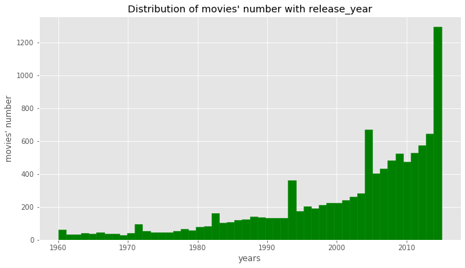

```python
plt.style.use('ggplot')
df['release_year'].hist(figsize=(11,6), bins=50 , Color= 'green');
plt.title("Distribution of movies' number with release_year")
plt.xlabel('years')
# plt.xlim(1960,2015)
plt.ylabel("movies' number");
```

[output not shown]

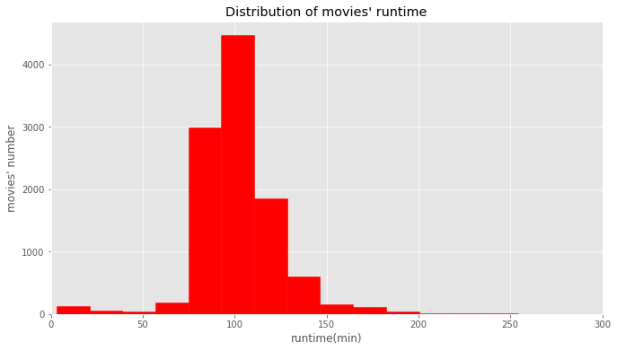

```python
df['runtime'].hist(figsize=(11,6), bins=50 , Color= 'red' );
plt.title("Distribution of movies' runtime")
plt.xlabel('runtime(min)')
plt.ylabel("movies' number");
plt.xlim(0,300)
```

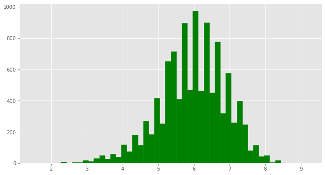

```python
df['vote_average'].hist(figsize=(11,6), bins=50 , Color= 'green');
```

- distribution of movies' vote rate is slightly left skewed.
- most of movies' vote rate is around 6.

## Exploring relation between different movies properties

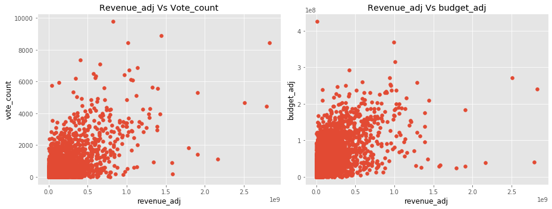

```python
fig, axes = plt.subplots(1,2, figsize=(13, 5))

axes[0].scatter(x = df['revenue_adj'], y = df['vote_count']);
axes[0].set_xlabel('revenue_adj' ,c='black')
axes[0].set_ylabel('vote_count' ,c='black')
axes[0].set_title('Revenue_adj Vs Vote_count');

axes[1].scatter(x = df['revenue_adj'], y = df['budget_adj']);
axes[1].set_xlabel('revenue_adj' ,c='black')
axes[1].set_ylabel('budget_adj' ,c='black')
axes[1].set_title('Revenue_adj Vs budget_adj');

plt.tight_layout();
```

Above graph that 'revenue_adj' of a movie has a **positive relation with Vote count ,budget of movie**.

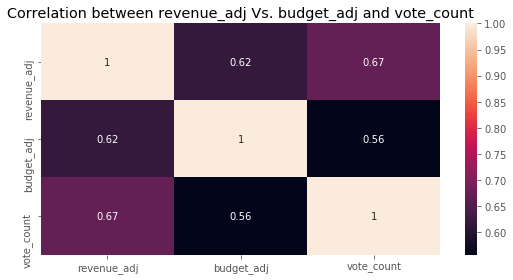

```python
plt.figure(figsize=(8,4))
sns.heatmap(df[['revenue_adj','budget_adj','vote_count']].corr(),annot=True)
plt.title('Correlation between revenue_adj Vs. budget_adj and vote_count')
plt.tight_layout();
```

### Question 1: What kinds of properties are associated with movies that have high revenues?

> Above Correlation heatmap graph that 'revenue_adj' of a movie has a **positive relation/correlation with Vote count ,budget of movie**

### Question 2 Which genres are most popular from year to year?

```python
# items_extractList function to split mixed items by '|' in a column into a list sothat it will be easy to explode later

def items_extractList(complex_items):
    items_lst =[]

    if '|' in str(complex_items):
        items_lst += complex_items.split('|')
    else:
        items_lst.append(complex_items)

    return items_lst
```

```python
# using items_extractList function to split mixed items in generes into a list sothat it will be easy to explode later

df['genres'] = df['genres'].apply(items_extractList)
```

```python
# creating data frame for release_year, Popularity and generes
df_mostPopular = df[['release_year','genres','popularity']]

df_mostPopular = df_mostPopular.explode('genres')
```

```python
#filtering the mostPopular generes every year by grouping [release_year and generes] then aggregration by average of Popularity

df_mostPopular_mean = df_mostPopular.groupby(['release_year','genres']).mean()
df_mostPopular_mean = df_mostPopular_mean.reset_index()

#sorting generes by highest Popularity values
df_mostPopular_mean = df_mostPopular_mean.sort_values(by='popularity',ascending = False ,ignore_index=True)
```

```python
df_mostPopular_mean.head()
```

|  | release_year | genres | popularity |
| --- | --- | --- | --- |
| 0 | 2015 | Adventure | 3.283786 |
| 1 | 2015 | Western | 3.178796 |
| 2 | 1961 | Animation | 2.631987 |
| 3 | 1967 | Animation | 2.550704 |
| 4 | 2014 | Adventure | 2.430526 |

```python
# dropping duplicate rows based on 'release_year' Values
df_mostPopular_mean = df_mostPopular_mean.drop_duplicates(subset='release_year' , keep='first')
df_mostPopular_mean = df_mostPopular_mean.sort_values(by='release_year',ascending = False ,ignore_index=True)
df_mostPopular_mean.head(10)
```

|  | release_year | genres | popularity |
| --- | --- | --- | --- |
| 0 | 2015 | Adventure | 3.283786 |
| 1 | 2014 | Adventure | 2.430526 |
| 2 | 2013 | Adventure | 1.294491 |
| 3 | 2012 | Western | 1.732778 |
| 4 | 2011 | Western | 1.175800 |
| 5 | 2010 | Adventure | 1.378913 |
| 6 | 2009 | Adventure | 1.153656 |
| 7 | 2008 | Adventure | 1.008385 |
| 8 | 2007 | Fantasy | 0.957349 |
| 9 | 2006 | Fantasy | 1.023134 |

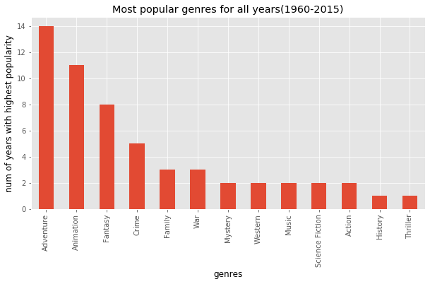

```python
df_mostPopular_mean['genres'].value_counts().plot.bar(figsize=(10,5));
plt.xlabel('genres' ,c='black')
plt.ylabel('num of years with highest popularity' ,c='black')
plt.title('Most popular genres for all years(1960-2015)');
```

### Question 2 Which genres are most popular from year to year?

> we can observe from above graph that the top 4 popular genres are [**'Adventure' ,'Animation','Fantasy', 'Crime'**]

### Question 3 : What is the director name who has the most top yearly-voting rate over all years?

```python
df.info()
```

```
<class 'pandas.core.frame.DataFrame'>
Int64Index: 10706 entries, 0 to 10865
Data columns (total 13 columns):
 #   Column          Non-Null Count  Dtype
---  ------          --------------  -----
 0   id              10706 non-null  int64
 1   popularity      10706 non-null  float64
 2   original_title  10706 non-null  object
 3   cast            10706 non-null  object
 4   director        10706 non-null  object
 5   runtime         10706 non-null  float64
 6   genres          10706 non-null  object
 7   release_date    10706 non-null  datetime64[ns]
 8   vote_count      10706 non-null  int64
 9   vote_average    10706 non-null  float64
 10  release_year    10706 non-null  int64
 11  budget_adj      10706 non-null  float64
 12  revenue_adj     10706 non-null  float64
dtypes: datetime64[ns](1), float64(5), int64(3), object(4)
memory usage: 1.1+ MB
```

```python
df['director'].str.contains('|').value_counts()
```

```
True    10706
Name: director, dtype: int64
```

```python
df_direct_mostvoterate = df[['release_year','director','original_title','vote_average']]
```

```python
#filtering the highest vote-rated movie's directory name yearly by grouping [release_year and director] then aggregration by max of vote_average

df_direct_mostvoterate = df_direct_mostvoterate.groupby(['release_year']).max()
df_direct_mostvoterate = df_direct_mostvoterate.reset_index()

df_direct_mostvoterate.head()
```

|  | release_year | director | original_title | vote_average |
| --- | --- | --- | --- | --- |
| 0 | 1960 | Wolf Rilla | Village of the Damned | 8.0 |
| 1 | 1961 | Yuri Chulyukin | West Side Story | 7.5 |
| 2 | 1962 | Vittorio De Sica\|Federico Fellini\|Luchino Visc... | What Ever Happened to Baby Jane? | 7.7 |
| 3 | 1963 | Wolfgang Reitherman | X: The Man with the X-Ray Eyes | 7.5 |
| 4 | 1964 | Ubaldo Ragona\|Sidney Salkow | Zulu | 7.7 |

```python
# using items_extractList function to split mixed items in director into a list sothat it will be easy to explode later

df_direct_mostvoterate['director'] = df_direct_mostvoterate['director'].apply(items_extractList)
df_direct_mostvoterate = df_direct_mostvoterate.explode('director')
```

```python
df_direct_mostvoterate.head()
```

|  | release_year | director | original_title | vote_average |
| --- | --- | --- | --- | --- |
| 0 | 1960 | Wolf Rilla | Village of the Damned | 8.0 |
| 1 | 1961 | Yuri Chulyukin | West Side Story | 7.5 |
| 2 | 1962 | Vittorio De Sica | What Ever Happened to Baby Jane? | 7.7 |
| 2 | 1962 | Federico Fellini | What Ever Happened to Baby Jane? | 7.7 |
| 2 | 1962 | Luchino Visconti | What Ever Happened to Baby Jane? | 7.7 |

```python
woody = df_direct_mostvoterate[df_direct_mostvoterate['director']== 'Woody Allen']
len(df_direct_mostvoterate[df_direct_mostvoterate['director']== 'Woody Allen'])
```

```
22
```

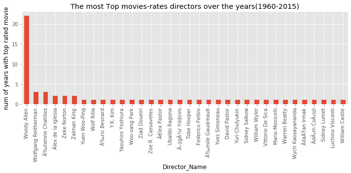

```python
df_direct_mostvoterate['director'].value_counts().plot.bar(figsize=(10,5));
plt.xlabel('Director_Name' ,c='black')
plt.ylabel('num of years with top rated movie' ,c='black')
plt.title('The most Top movies-rates directors over the years(1960-2015)');
plt.tight_layout();
```

#### Question 4 : which months mostly have the highest movies number released for last 10 years ?

```python
# extract month value from release_date column and create new column 'month'
df['month'] = df['release_date'].apply(lambda x: x.strftime('%B'))

# filter on last 10 years and get counts of movies per month
df_top_month = df[df['release_year']> 2005]['month'].value_counts()
```

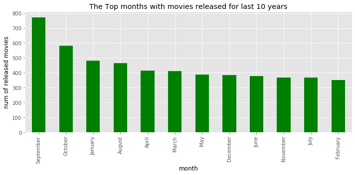

```python
#plotting The Top months with movies released for last 10 years

df_top_month.plot.bar(figsize=(10,5),color='green');
plt.xlabel('month' ,c='black')
plt.ylabel('num of released movies' ,c='black')
plt.title('The Top months with movies released for last 10 years');
plt.tight_layout();
```

### Question 4 : which months mostly have the highest movies number released for last 10 years ?

> we can observe from above graph that The Top months with the highest movies released for last 10 years are [**September**] then [**October**]

### Question 5 : which genres have the highest mean revenues over the last 10 years ?

```python
df_highrevenue = df[df['release_year']> 2005][['release_year','genres','revenue_adj','budget_adj']]
df_highrevenue = df_highrevenue.explode('genres')
df_highrevenue.head()
```

|  | release_year | genres | revenue_adj | budget_adj |
| --- | --- | --- | --- | --- |
| 0 | 2015 | Action | 1.392446e+09 | 1.379999e+08 |
| 0 | 2015 | Adventure | 1.392446e+09 | 1.379999e+08 |
| 0 | 2015 | Science Fiction | 1.392446e+09 | 1.379999e+08 |
| 0 | 2015 | Thriller | 1.392446e+09 | 1.379999e+08 |
| 1 | 2015 | Action | 3.481613e+08 | 1.379999e+08 |

```python
df_highrevenue = df_highrevenue.groupby(['genres']).agg(
    {         'revenue_adj':"mean",    # mean revenue_adj per genre
         'budget_adj': "mean",  # mean budget_adj per genre
    })
df_highrevenue.head()
```

| genres | revenue_adj | budget_adj |
| --- | --- | --- |
| Action | 1.193001e+08 | 4.188669e+07 |
| Adventure | 1.946445e+08 | 6.267154e+07 |
| Animation | 1.330612e+08 | 4.151244e+07 |
| Comedy | 6.174060e+07 | 2.144536e+07 |
| Crime | 6.228957e+07 | 2.536133e+07 |

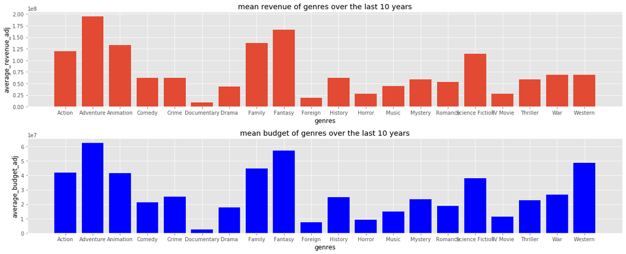

```python
fig, axes = plt.subplots(2,1, figsize=(17, 7))

axes[0].bar(x = df_highrevenue.index, height = df_highrevenue['revenue_adj']);
axes[0].set_xlabel('genres' ,c='black')
axes[0].set_ylabel('average_revenue_adj' ,c='black')
axes[0].set_title('mean revenue of genres over the last 10 years');

axes[1].bar(x = df_highrevenue.index, height = df_highrevenue['budget_adj'],color='blue');
axes[1].set_xlabel('genres' ,c='black')
axes[1].set_ylabel('average_budget_adj' ,c='black')
axes[1].set_title('mean budget of genres over the last 10 years');

plt.tight_layout();
```

we can observe from above graph that top genre having the highest mean revenues over the last 10 years is **Adventure** then **Fantasy**.

```python
df_highrevenue[df_highrevenue['revenue_adj'] == df_highrevenue['revenue_adj'].max()]
```

| genres | revenue_adj | budget_adj |
| --- | --- | --- |
| Adventure | 1.946445e+08 | 6.267154e+07 |

### Question 5 : which genres have the highest mean revenues over the last 10 years ?

> we can observe from above graph that top genre having the highest mean revenues over the last 10 years is **Adventure** with mean revenue around **194.6 million dollars** then **Fantasy**.

## Conclusions

> The top 4 popular Movies' genres are **'Adventure' ,'Animation','Fantasy', 'Crime'**.

> The Top 2 months with the highest movies released [**Movies season**] for last 10 years are **September** then **October**.

> The movies with **high revenues** are associated with **high Votes count** and **the budgets of the movies**.

> the top genre having the highest mean revenues over the last 10 years is **Adventure** with mean revenue around **194.6 million dollars** then **Fantasy**.
- **Limitions:** we have below Limitions in Data set that may affect our data analysis:
> - we have null/missing data in columns ('cast' , 'director' ,'tagline','keywords','genres', 'production_companies').
> - we observed unreasonable zero values for budget & revenue & run time.

>   ```
>   - num of rows with zero value in revenue_adj : 5888
>   - num of rows with zero value in budget_adj : 5578
>   - num of rows with zero value in runtime : 28
>   ```